# Data Visualization with `matplotlib`

Monte Lunacek

[figure not shown]

## Objectives

- Understand the different between `pylab` and `pyplot`.
- Understand the basic components of a plot.
- Understand style
- Give you enough information to use the [gallery](http://matplotlib.org/gallery#).
- Reference for several standard plots.
  - histogram, density, boxplot (when appropriate)
  - scatter, line, hexbin
  - contour, false-color

## References

This tutorial based on some of the following excellent content.

- [J.R. Johansson's tutorial](http://nbviewer.ipython.org/github/jrjohansson/scientific-python-lectures/blob/master/Lecture-4-Matplotlib.ipynb)
- [Matplotlib tutorial by Jake Vanderplas](http://jakevdp.github.io/mpl_tutorial/)
- [Nicolas P. Rougier's tutorial](http://www.loria.fr/~rougier/teaching/matplotlib/)
- [Painless create beautiful matplotlib](http://blog.olgabotvinnik.com/post/58941062205/prettyplotlib-painlessly-create-beautiful-matplotlib)
- [Making matplotlib look like ggplot](http://messymind.net/2012/07/making-matplotlib-look-like-ggplot/)
- https://github.com/jakevdp/mpld3
- [Harvard CS109 Data Science Class](http://nbviewer.ipython.org/github/cs109/content/blob/master/lec_03_statistical_graphs.ipynb).

## Object and Functional Models

**Functional**

- Emulate `Matlab`
- Convension: *implicit state*

  ```
    from pylab import *
  ```

**Object-oriented**

- Not a flat model.
- `Figure`, `Axes`

  ```
    import matplotlib.pyplot as plt
  ```

Caution: redundant interface, namespace issues

## Enabling plotting

**IPython terminal**

```
ipython --pylab
ipython --matplotlib
```

**IPython notebook**

```
%pylab inline
%matplotlib inline

ipython notebook --pylab=inline
ipython notebook --matplotlib=inline
```

## The funtional `pylab` interface

- Loads all of `numpy` and `matplotlib` into the global namesapce.
- Great for interactive use.

```python
#inline to use with notebook (from pylab import *)
%pylab inline
```

```python
# make the plots smaller
rcParams['figure.figsize'] = 8, 4
```

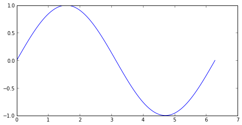

```python
x = linspace(0, 2*pi, 100)
y = sin(x)
plot(x, y)
show()
```

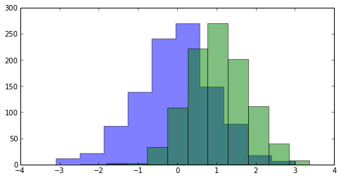

```python
hist(randn(1000), alpha=0.5, histtype='stepfilled')
hist(0.75*randn(1000)+1, alpha=0.5) #hist?
show()
```

```python
#hist?
```

Quick, easy, simple plots.

## Object-oriented `pyplot` interface

- No global variables
- Separates style from graph
- Can easily have multiple subplots

```python
#restart notebook
%matplotlib inline
import matplotlib.pyplot as plt
import numpy as np
```

```python
import matplotlib as mpl
mpl.rcParams['figure.figsize'] = 8, 4
```

```python
# SKIP this step if you are running locally.  AWS only.
mpl.rcParams['backend'] = 'TkAgg'
```

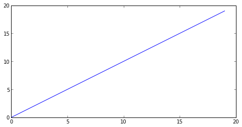

```python
plot(range(20))
```

### The `figures` and `axes` objects

First, we create a blank figure. Then we add a subpot.

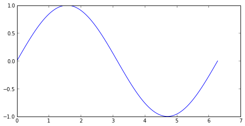

```python
x = np.linspace(0, 2*np.pi, 100) #same as before
y = np.sin(x)

fig = plt.figure()
ax = fig.add_subplot(1,1,1) # 1 row, 1 col, graphic 1
ax.plot(x, y)
fig.show()
```

### Multiple subplots

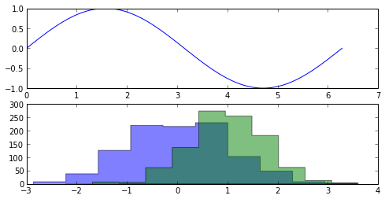

```python
fig = plt.figure()

ax1 = fig.add_subplot(2,1,1) # 1 row, 2 cols, graphic 1
ax2 = fig.add_subplot(2,1,2) # graphic 2

ax1.plot(x, y)

ax2.hist(np.random.randn(1000), alpha=0.5, histtype='stepfilled')
ax2.hist(0.75*np.random.randn(1000)+1, alpha=0.5, histtype='stepfilled')

fig.show()
```

### The `plt.subplots()` command

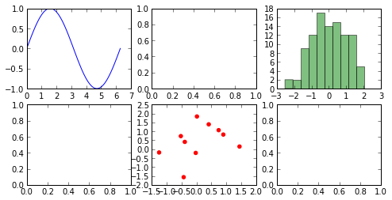

```python
fig, ax = plt.subplots(2,3)

ax[0,0].plot(x, y)
ax[0,2].hist(np.random.randn(100), alpha=0.5, color="g")
ax[1,1].scatter(np.random.randn(10), np.random.randn(10), color="r")

fig.show()
```

plt.plot?

```
==========  ========
character   color
==========  ========
'b'         blue
'g'         green
'r'         red
'c'         cyan
'm'         magenta
'y'         yellow
'k'         black
'w'         white
==========  ========
```

## The `subplot2grid` command

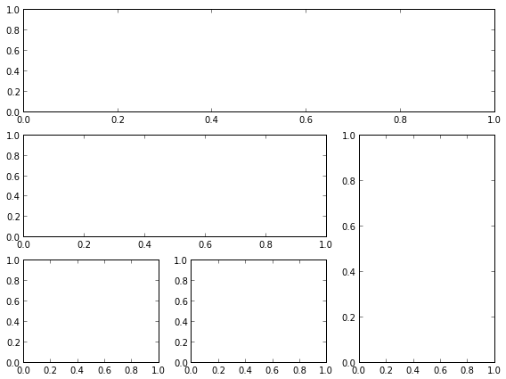

```python
fig = plt.figure(figsize=(8,6))
ax1 = plt.subplot2grid((3,3), (0,0), colspan=3)
ax2 = plt.subplot2grid((3,3), (1,0), colspan=2)
ax3 = plt.subplot2grid((3,3), (1,2), rowspan=2)
ax4 = plt.subplot2grid((3,3), (2,0))
ax5 = plt.subplot2grid((3,3), (2,1))
fig.tight_layout()
fig.show()
```

### Sharing axis values

```
(3,)
```

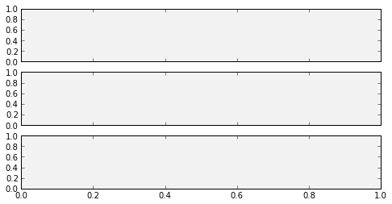

```python
fig, axes = plt.subplots( 3, 1, sharex = True)
for ax in axes:
    ax.set_axis_bgcolor('0.95')
fig.show()
print axes.shape
```

```
(2, 2)
```

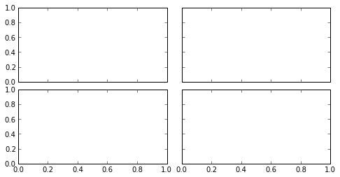

```python
fig, axes = plt.subplots( 2, 2, sharex = True, sharey = True)
plt.subplots_adjust( wspace = 0.1, hspace = 0.1)
fig.show()
print axes.shape
```

## Matplotlib Style

Who doesn't like the feel and [colors](http://colorbrewer2.org/) of [ggplot](http://ggplot2.org/)?

[figure not shown]

How do we make matplotlib look like this?

Useful exercise (even if you don't appreciate this). References:

- [Painless create beautiful matplotlib](http://blog.olgabotvinnik.com/post/58941062205/prettyplotlib-painlessly-create-beautiful-matplotlib)
- [Making matplotlib look like ggplot](http://messymind.net/2012/07/making-matplotlib-look-like-ggplot/)

### The `scatter` plot

```python
%matplotlib inline
import os
import pandas as pd
import numpy as np
import matplotlib.pyplot as plt
import matplotlib as mpl
```

```python
cars = pd.read_csv(os.path.join('data','cars.csv'))
cars.head()
```

|  | type | mpg | cyl | disp | hp | drat | wt | qsec | vs | am | gear | carb |
| --- | --- | --- | --- | --- | --- | --- | --- | --- | --- | --- | --- | --- |
| 0 | MazdaRX4 | 21.0 | 6 | 160 | 110 | 3.90 | 2.620 | 16.46 | 0 | 1 | 4 | 4 |
| 1 | MazdaRX4Wag | 21.0 | 6 | 160 | 110 | 3.90 | 2.875 | 17.02 | 0 | 1 | 4 | 4 |
| 2 | Datsun710 | 22.8 | 4 | 108 | 93 | 3.85 | 2.320 | 18.61 | 1 | 1 | 4 | 1 |
| 3 | Hornet4Drive | 21.4 | 6 | 258 | 110 | 3.08 | 3.215 | 19.44 | 1 | 0 | 3 | 1 |
| 4 | HornetSportabout | 18.7 | 8 | 360 | 175 | 3.15 | 3.440 | 17.02 | 0 | 0 | 3 | 2 |

5 rows × 12 columns

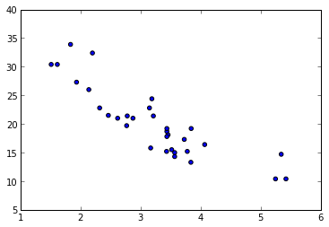

```python
fig, ax = plt.subplots(figsize=(6,4))
ax.scatter(cars['wt'], cars['mpg'])
fig.show()
```

### Changing style

Check out [color brewer](http://colorbrewer2.org/) and [brewer2mpl wiki](https://github.com/jiffyclub/brewer2mpl/wiki)

```python
color = ['#66c2a5','#fc8d62','#8da0cb']
```

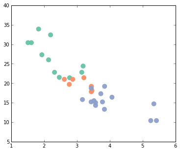

```python
fig, ax = plt.subplots(figsize=(6,5))
for i, cyl in enumerate([4,6,8]):
    df = cars[cars['cyl'] == cyl]

    ax = plt.scatter(df['wt'],
                     df['mpg'],
                     s=100,
                     alpha=0.95,
                     edgecolor='none',
                     c=color[i])
fig.show()
```

### The beauty of `objects`

```python
def base_figure():
    fig, ax = plt.subplots(figsize=(6,5))
    for index, cyl in enumerate([4,6,8]):
        df = cars[cars['cyl'] == cyl]
        ax.scatter(df['wt'], df['mpg'], c=color[index], s=100, alpha=0.75, edgecolor='none')
    return fig, ax
```

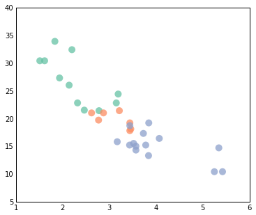

```python
fig, ax = base_figure()

ax.xaxis.set_ticks_position('none')
ax.yaxis.set_ticks_position('none')

fig.show()
```

```python
def remove_ticks(ax):
    ax.xaxis.set_ticks_position('none')
    ax.yaxis.set_ticks_position('none')

def remove_splines(ax, spl):
    for s in spl:
        ax.spines[s].set_visible(False)

def modify_splines(ax, lwd, col):
    for s in ['bottom', 'left','top','right']:
        ax.spines[s].set_linewidth(lwd)
        ax.spines[s].set_color(col)
```

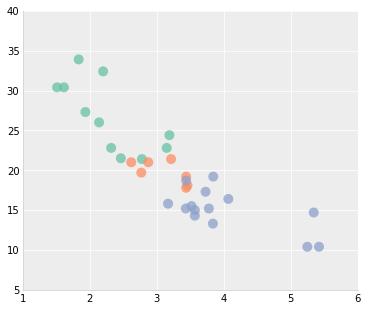

```python
fig, ax = base_figure()

remove_ticks(ax)
modify_splines(ax, lwd=0.75, col='0.8')
remove_splines(ax, ['top','right'])

ax.patch.set_facecolor('0.93')
ax.grid(True, 'major', color='0.98', linestyle='-', linewidth=1.0)
ax.set_axisbelow(True)

fig.show()
```

### Define custom transformations

```python
def ggplot(ax):

    remove_ticks(ax)
    modify_splines(ax, lwd=0.75, col='0.8')
    remove_splines(ax, ['top','right'])

    ax.patch.set_facecolor('0.93')
    ax.grid(True, 'major', color='0.98', linestyle='-', linewidth=1.0)
    ax.set_axisbelow(True)
```

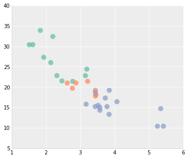

```python
fig, ax = base_figure()
ggplot(ax)
fig.show()
```

### Legends

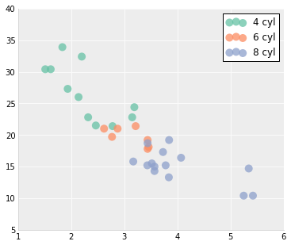

```python
def base_figure():

    fig, ax = plt.subplots(figsize=(6,5))
    for index, cyl in enumerate([4,6,8]):
        df = cars[cars['cyl'] == cyl]

        tmp = '{c} cyl'
        tmp = tmp.format(c=cyl)

        ax.scatter(df['wt'],
                   df['mpg'],
                   c=color[index],
                   s=100,
                   alpha=0.75,
                   edgecolor='none',
                   label=tmp)  # adding a label

    return fig, ax

fig, ax = base_figure()

ax.legend(loc='best')

ggplot(ax)

fig.show()
```

```python
def nice_legend(ax):
    if ax.legend_ is not None:
        ax.legend_.get_frame().set_linewidth(0)
        ax.legend_.get_frame().set_alpha(0.5)
```

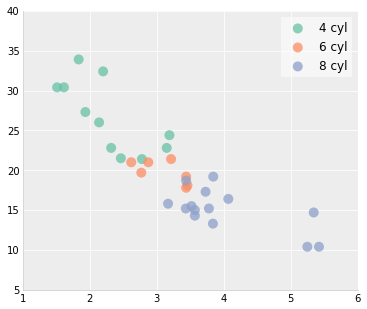

```python
fig, ax = base_figure()

ax.legend(loc='best', scatterpoints=1) # for a single point

ggplot(ax)
nice_legend(ax)

fig.show()
```

### Changing your default style

You can add *some* custom styles in your `~/.matplotlib/matplotlibrc` file.

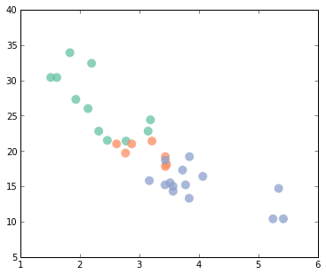

```python
fig, ax = base_figure()
fig.show()
```

### Setting the `mpl.rcParams`

The default figue size.

```python
mpl.rcParams['figure.figsize'] = 8, 4
```

Change the axes background color, turn on grid lines, change the color.

```python
mpl.rcParams['axes.facecolor'] = '0.93'
mpl.rcParams['axes.grid'] = True
mpl.rcParams['grid.linestyle'] = '-'
mpl.rcParams['grid.linewidth'] = 1
mpl.rcParams['grid.color'] = '1.0'
mpl.rcParams['axes.axisbelow'] = True
mpl.rcParams['axes.linewidth'] = 0.5
mpl.rcParams['axes.edgecolor'] = '0.7' #can't remove some
mpl.rcParams['xtick.major.size'] = 0.0
mpl.rcParams['ytick.major.size'] = 0.0
```

Modify the legend.

```python
mpl.rcParams['legend.fancybox'] = True
#mpl.rcParams['scatterpoints'] = 1 # fails on AWS?
mpl.rcParams['legend.frameon'] = False
```

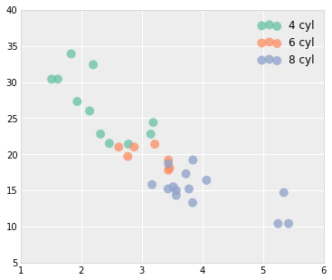

```python
fig, ax = base_figure()
ax.legend(loc='best')
fig.show()
```

And many more options....

```python
mpl.rcParams.keys()[:10]
```

```
['agg.path.chunksize',
 'animation.bitrate',
 'animation.codec',
 'animation.ffmpeg_args',
 'animation.ffmpeg_path',
 'animation.frame_format',
 'animation.mencoder_args',
 'animation.mencoder_path',
 'animation.writer',
 'axes.axisbelow']
```

Let's save that for later...

```python
import json

with open('mplrc.json','w') as output:
    output.write(json.dumps(mpl.rcParams))
```

### Tricks with `itertools` and `functools`

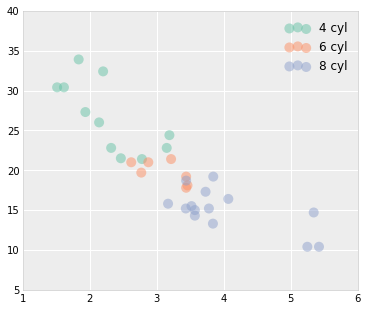

```python
fig, ax = plt.subplots(figsize=(6,5))

for index, cyl in enumerate([4,6,8]):
    df = cars[cars['cyl'] == cyl]
    ax.scatter(df['wt'],
               df['mpg'],
               c=color[index],
               s=100,
               alpha=0.5,
               edgecolor='none',
               label='{0} cyl'.format(cyl))  # adding a label

ax.legend(loc='best')
fig.show()
```

```python
import itertools
from functools import partial
```

```python
color_iter = itertools.cycle(color)
partial_scatter = partial(plt.scatter, s=100, alpha=0.75, edgecolor='none')
```

```python
type(color_iter)
print next(color_iter)
```

```
#66c2a5
```

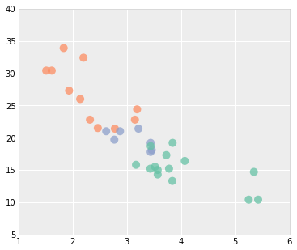

```python
fig, ax = plt.subplots(figsize=(6,5))
for cyl in [4,6,8]:
    df = cars[cars['cyl'] == cyl]

    ax = partial_scatter(df['wt'], df['mpg'],
                         c=next(color_iter),
                         label='{0} cyl'.format(cyl))

fig.show()
```

## Examples

```python
%matplotlib inline
import numpy as np
import matplotlib.pyplot as plt
import matplotlib as mpl
```

### The `line` graph

plt.plot?

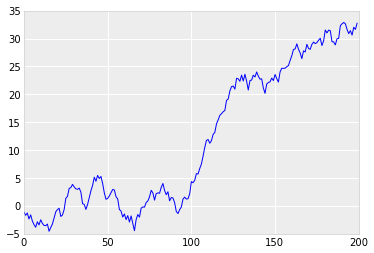

```python
fig, ax = plt.subplots()
ax.plot(np.random.randn(200).cumsum())
fig.show()
#plt.plot(np.random.randn(200).cumsum())
```

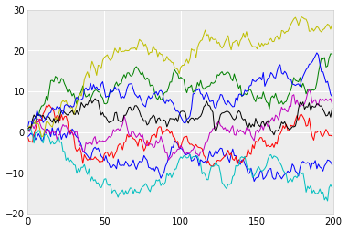

```python
fig, ax = plt.subplots()
for i in range(8):
    ax.plot(np.random.randn(200).cumsum())
fig.show()
```

### Histogram

plt.hist?

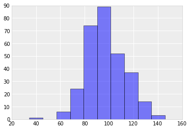

```python
mu = 100
sigma = 15
x = mu + sigma * np.random.randn(300)

fig, ax = plt.subplots()
ax.hist(x, alpha=0.5, bins=10)
fig.show()
```

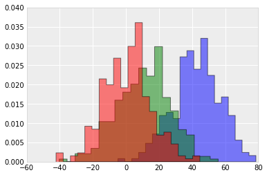

```python
fig, ax = plt.subplots()
for i in range(3):
    x = 20.0*np.random.randn() + sigma*np.random.randn(300)
    ax.hist(x, normed=1, alpha=0.5, histtype='stepfilled', bins=20)
fig.show()
```

### Kernel Density Estimates

```python
from sklearn.neighbors.kde import KernelDensity
```

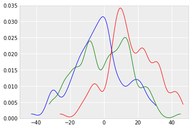

```python
fig, ax = plt.subplots()
for i in range(3):

    data = 20.0*np.random.randn() + sigma*np.random.randn(100)
    x = np.linspace(data.min(), data.max(), 100)

    # For sklearn
    data = data.reshape(-1, 1)
    x = x.reshape(-1, 1)

    kde = KernelDensity(bandwidth=3).fit(data)  # you can adjust the 'bandwidth' parameter
    density = np.exp(kde.score_samples(x))
    ax.plot(x, density)

fig.show()
```

### `Scipy.stats`

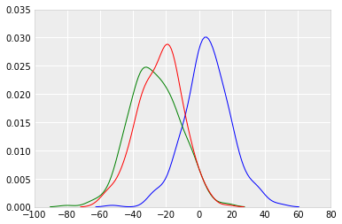

```python
from scipy import stats

fig, ax = plt.subplots()
for i in range(3):

    x = 20.0*np.random.randn() + sigma*np.random.randn(300)
    xd = np.linspace(min(x)-10, max(x)+10, 100)
    density = stats.kde.gaussian_kde(x)
    ax.plot(xd, density(xd))

fig.show()
```

### `fill_between`

```python
import itertools
colors = itertools.cycle(mpl.rcParams['axes.color_cycle'])
```

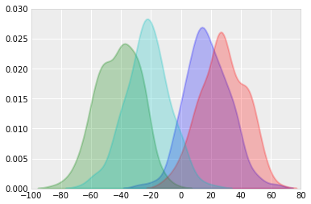

```python
fig, ax = plt.subplots()
for i in range(4):

    x = 20.0*np.random.randn() + sigma*np.random.randn(300)
    xd = np.linspace(min(x)-10, max(x)+10, 100)
    density = stats.kde.gaussian_kde(x)

    ax.fill_between(xd, 0, density(xd), alpha=0.25,
                    color=next(colors),
                    linewidth=2)

fig.show()
```

### Combined `hist` and `kde`

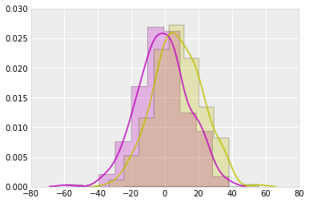

```python
fig, ax = plt.subplots()
for i in range(2):

    x = 20.0*np.random.randn() + sigma*np.random.randn(300)
    xd = np.linspace(min(x)-10, max(x)+10, 100)
    density = stats.kde.gaussian_kde(x)
    c = next(colors)

    ax.hist(x, normed=1, alpha=0.25, color=c, histtype='stepfilled')
    ax.plot(xd, density(xd), alpha=0.75, color=c, linewidth=2)

fig.show()
```

### Bar charts

Adapted from [Harvard CS109](http://nbviewer.ipython.org/github/cs109/content/blob/master/lec_03_statistical_graphs.ipynb).

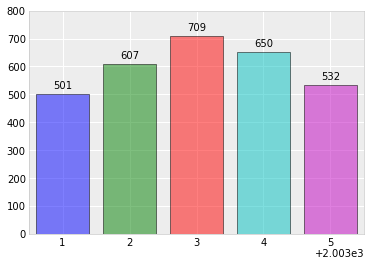

```python
years = [2004, 2005, 2006, 2007, 2008]
heights = [501, 607, 709, 650, 532]
box_colors = mpl.rcParams['axes.color_cycle']

fig, ax = plt.subplots()

ax.bar(np.array(years)-0.4, heights, color=box_colors, alpha=0.5)

ax.set_xlim(2003.5, 2008.5)
ax.set_ylim(0,800)

for x, y in zip(years, heights):
    plt.annotate('{0}'.format(y), (x, y + 20), ha='center')

fig.show()
```

### The `box` plot

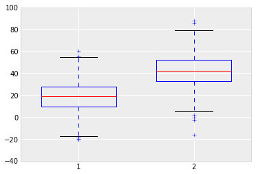

```python
fig, ax = plt.subplots()

d1 = 20.0*np.random.randn() + sigma*np.random.randn(300)
d2 = 20.0*np.random.randn() + sigma*np.random.randn(300)

data = [d1, d2]
bp = ax.boxplot(data, widths=0.65)

fig.show()
```

### Error bars

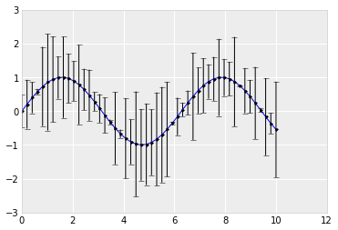

```python
x = np.linspace(0, 10, 50)
xerr = np.random.normal(np.sin(x), 0.4)
y = np.sin(x)

fig, ax = plt.subplots()

ax.plot(x, y)
ax.errorbar(x, y, xerr, fmt='.k')

fig.show()
```

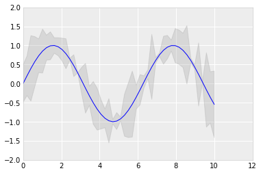

```python
fig, ax = plt.subplots()

ax.plot(x, y)
ad = abs(y-xerr)
ax.fill_between(x, y - ad, y + ad, color='0.5', alpha=0.2)

fig.show()
```

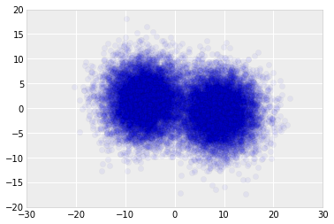

```python
from sklearn.datasets import make_blobs

X, _ = make_blobs(n_samples=20000, centers=2, random_state=37, cluster_std=4)
x = X[:,0]
y = X[:,1]

fig, ax = plt.subplots()

ax.plot(x,y, 'o', alpha=0.05)

fig.show()
```

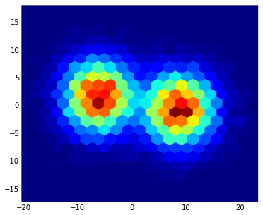

```python
fig, ax = plt.subplots(figsize=(6,5))

ax.hexbin(x, y, gridsize=20)

fig.show()
```

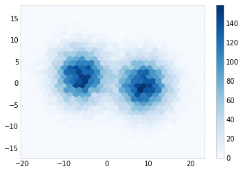

```python
blues=plt.get_cmap('Blues')

fig, ax = plt.subplots()

tmp = ax.hexbin(x, y, gridsize=30, cmap=blues)
fig.colorbar(tmp, ax=ax)
fig.show()
```

### Contour

Create a simple surface.

```python
x = np.linspace(-1, 1, 50)
y = np.linspace(-2, 2, 50)

X, Y = np.meshgrid(x, y)
z = X*X + Y*Y + X*Y
```

Default countour.

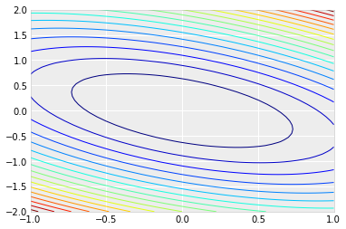

```python
fig, ax = plt.subplots()

ax.contour(x, y, z, 20)

fig.show()
```

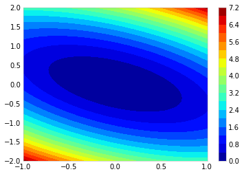

```python
fig, ax = plt.subplots()

con = ax.contourf(x, y, z, 20)

fig.colorbar(con, ax=ax)
fig.show()
```

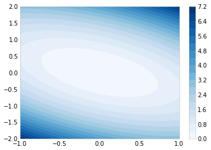

```python
fig, ax = plt.subplots()

tmp = ax.contour(x, y, z, 20, cmap=blues, alpha=0.9)
con = ax.contourf(x, y, z, 20, cmap=blues, alpha=1.)

fig.colorbar(con, ax=ax)
fig.show()
```

### False-color

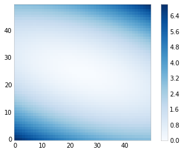

```python
fig, ax = plt.subplots()

im = ax.imshow(z, cmap=blues,
               interpolation='nearest',
               origin='lower')
ax.grid(False)
#tmp = ax.contour(z, 20)

fig.colorbar(im, ax=ax)
fig.show()
```